# DATA605 ASSIGNMENT 11

```r
library(tidyverse)
```

# 1 Question 1

**Using the “cars” dataset in R, build a linear model for stopping distance as a function of speed and replicate the analysis of your textbook chapter 3 (visualization, quality evaluation of the model, and residual analysis.)**

## 1.1 Load Dataset

```r
data <- datasets::cars

data
```

| speed | dist |
| --- | --- |
| 4 | 2 |
| 4 | 10 |
| 7 | 4 |
| 7 | 22 |
| 8 | 16 |
| 9 | 10 |
| 10 | 18 |
| 10 | 26 |
| 10 | 34 |
| 11 | 17 |

[output cut: 40 more lines]

## 1.2 Visualization

The data set shows a linear relationship between variables Distance and Speed.

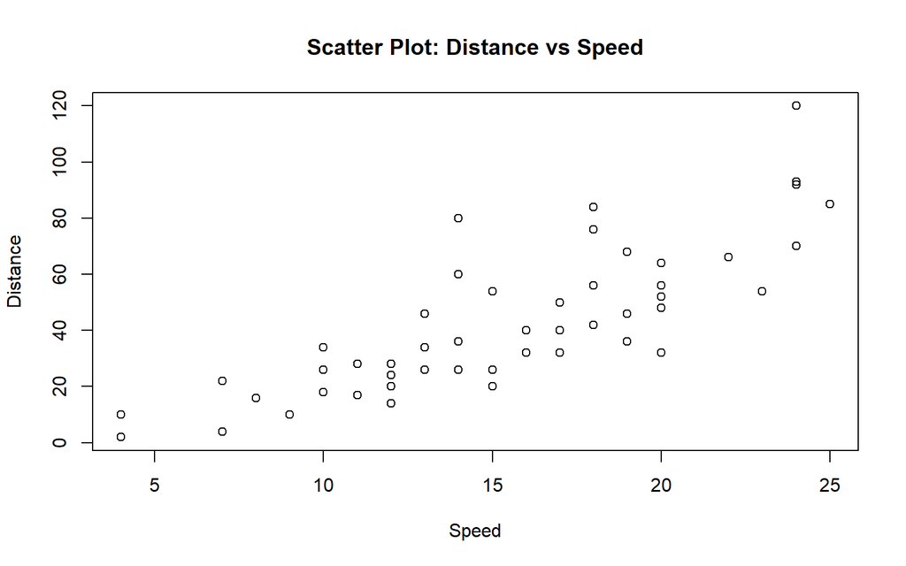

```r
plot(data,
     xlab = 'Speed',
     ylab = 'Distance',
     main = 'Scatter Plot: Distance vs Speed')
```

## 1.3 Build Simple Linear Model

A baseline model is built using all data points from the data.

```r
data.lm <- lm(dist ~ speed, data)

data.lm
```

```
##
## Call:
## lm(formula = dist ~ speed, data = data)
##
## Coefficients:
## (Intercept)        speed
##     -17.579        3.932
```

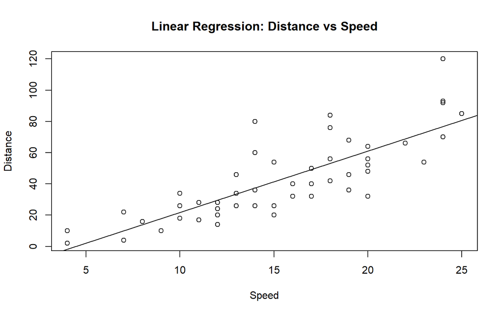

```r
plot(data,
     xlab = 'Speed',
     ylab = 'Distance',
     main = 'Linear Regression: Distance vs Speed')
abline(data.lm)
```

## 1.4 Quality Evaluation of Model

According to the model summary,

```r
summary(data.lm)
```

```
##
## Call:
## lm(formula = dist ~ speed, data = data)
##
## Residuals:
##     Min      1Q  Median      3Q     Max
## -29.069  -9.525  -2.272   9.215  43.201
##
## Coefficients:
##             Estimate Std. Error t value Pr(>|t|)
## (Intercept) -17.5791     6.7584  -2.601   0.0123 *
## speed         3.9324     0.4155   9.464 1.49e-12 ***
## ---
## Signif. codes:  0 '***' 0.001 '**' 0.01 '*' 0.05 '.' 0.1 ' ' 1
##
## Residual standard error: 15.38 on 48 degrees of freedom
## Multiple R-squared:  0.6511, Adjusted R-squared:  0.6438
## F-statistic: 89.57 on 1 and 48 DF,  p-value: 1.49e-12
```

## 1.5 Residual Analysis

The resudual plot doesn’t demostrate patterns of non-mormality, curvature or any violation of the constant variance assumption. However there are a few outliners with magnitudes of residual higher than 30 might have negative effect on building the reguression model.

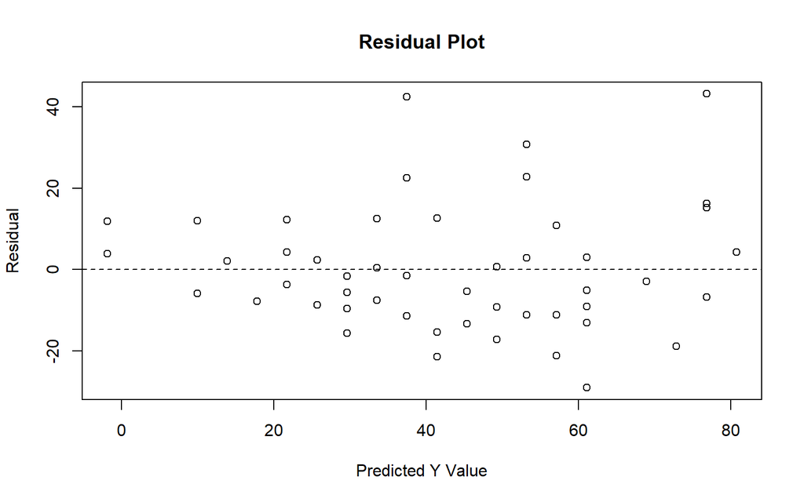

```r
plot(fitted(data.lm),
     resid(data.lm),
     xlab = 'Predicted Y Value',
     ylab = 'Residual',
     main = 'Residual Plot')
abline(h = 0, lty = 2)
```

The QQ-plot shows that the distribution of the residuals are close to normal except a few outliners.

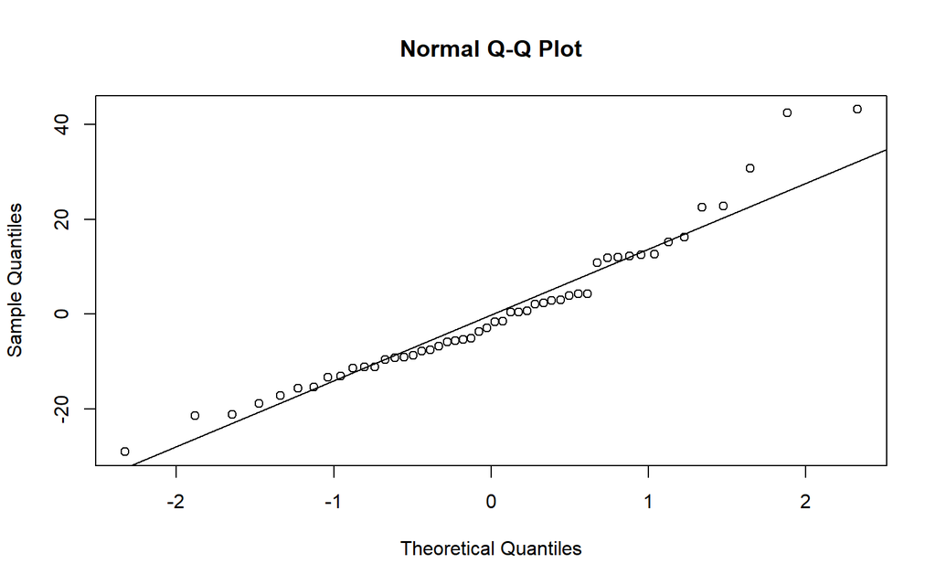

```r
qqnorm(resid(data.lm))
qqline(resid(data.lm))
```

## 1.6 Rebuid a Model Without Outliners

Removed data points with magnitude of residual higher than 30 and rebuilt the model.

1. The residuals demostrated a distribution closer to normal distritubion compared to the baseline model.
2. The P-values of the coeeficients demostrated stronger significance.
3. The multiple R-sqared is 0.7263, means that the model explained 72.63% of the data’s variation, higher than the baseline model.

```r
data.mod <- cbind(data, resid = resid(data.lm)) %>%
  filter(abs(resid) <= 30)

data.mod.lm <- lm(dist ~ speed, data.mod)

summary(data.mod.lm)
```

```
##
## Call:
## lm(formula = dist ~ speed, data = data.mod)
##
## Residuals:
##     Min      1Q  Median      3Q     Max
## -25.032  -7.686  -1.032   6.576  26.185
##
## Coefficients:
##             Estimate Std. Error t value Pr(>|t|)
## (Intercept) -15.1371     5.3053  -2.853  0.00652 **
## speed         3.6085     0.3302  10.928    3e-14 ***
## ---
## Signif. codes:  0 '***' 0.001 '**' 0.01 '*' 0.05 '.' 0.1 ' ' 1
##
## Residual standard error: 11.84 on 45 degrees of freedom
## Multiple R-squared:  0.7263, Adjusted R-squared:  0.7202
## F-statistic: 119.4 on 1 and 45 DF,  p-value: 3.003e-14
```

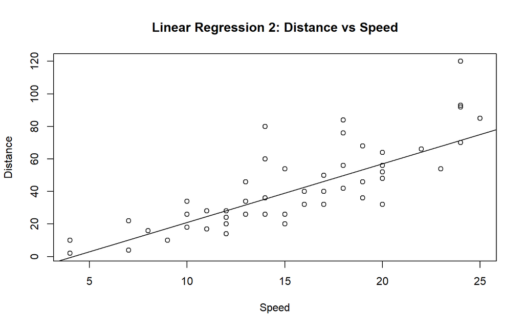

```r
plot(data,
     xlab = 'Speed',
     ylab = 'Distance',
     main = 'Linear Regression 2: Distance vs Speed')
abline(data.mod.lm)
```

The Resudual plot of the second model demostrated more significant normality.

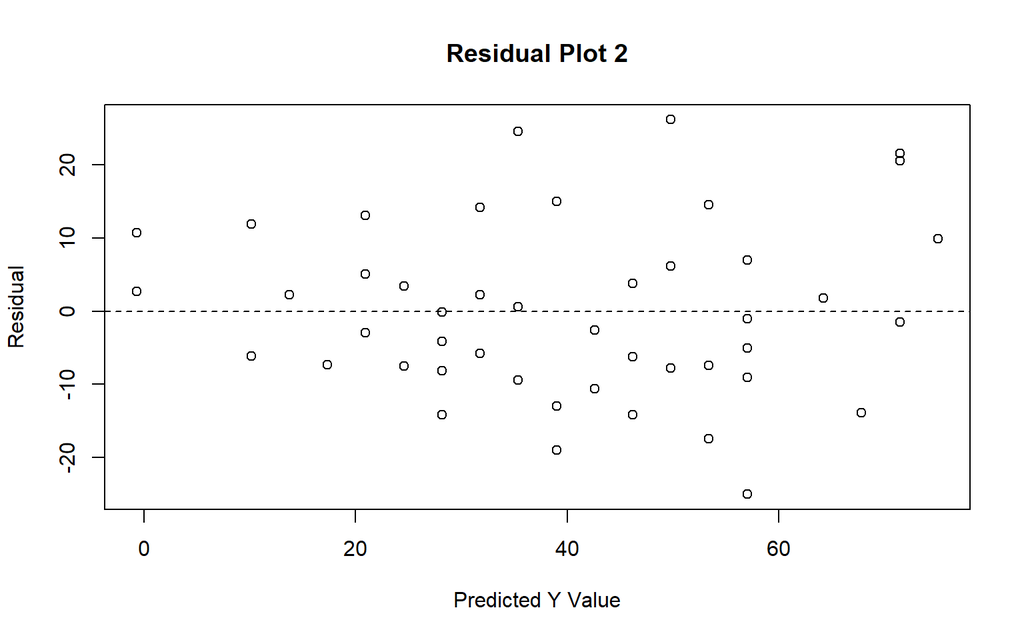

```r
plot(fitted(data.mod.lm),
     resid(data.mod.lm),
     xlab = 'Predicted Y Value',
     ylab = 'Residual',
     main = 'Residual Plot 2')
abline(h = 0, lty = 2)
```

The QQ-plot of the second model demostrated more significant normality as well.

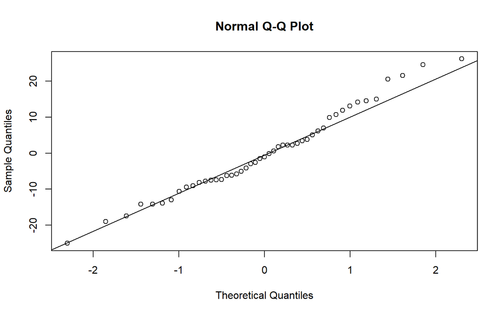

```r
qqnorm(resid(data.mod.lm))
qqline(resid(data.mod.lm))
```